# exploration_template-Copy3 slides

## Analyzing and Visualizing Loan Data

##### by (Junwei Tan)

[figure not shown]

### **[Dataset](https://docs.google.com/document/d/e/2PACX-1vQmkX4iOT6Rcrin42vslquX2_wQCjIa_hbwD0xmxrERPSOJYDtpNc_3wwK_p9_KpOsfA6QVyEHdxxq7/pub?embedded=True)** Detail

This dataset contains 113,937 loans with 81 variables on each loan, including loan amount, borrower rate (or interest rate), current loan status, borrower income, and many others. This data dictionary explains the variables in the data set. I am not explore all of the variables in the dataset! Only focus exploration on about 3 or 5 of them.

## These are the 'Key Words' represent the heaviest dataset that occupation very large portions of its type.

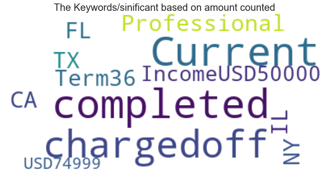

# Bivariate Exploration

### Now let’s dive in to find out the factors/feature that affect the loan outcome, and the outcome affecting the estimate return.

#### 1. Here are the features I will pick up for revieing the correlation with the outcome of bad/good loan. Ownership/original amount, current delinquent/prosper rating / income/Debt to income ratio.

#### 2. Here are the features I selecting for reviewing the correlation with estimate return. State, occupations, prosper rating, Loan Listing time.

## Estimate Return and Loan Status are the most pay attention features i will focus on,so the other factors will apply to Estimate income and Loan Status

## Loan Status VS. Occupations

#### Here is the plot i Categorize loan status into Good/Not Good. the Chart showing the loan Good/bad ratio for all occupations. it looks like job doesn't affect loan status

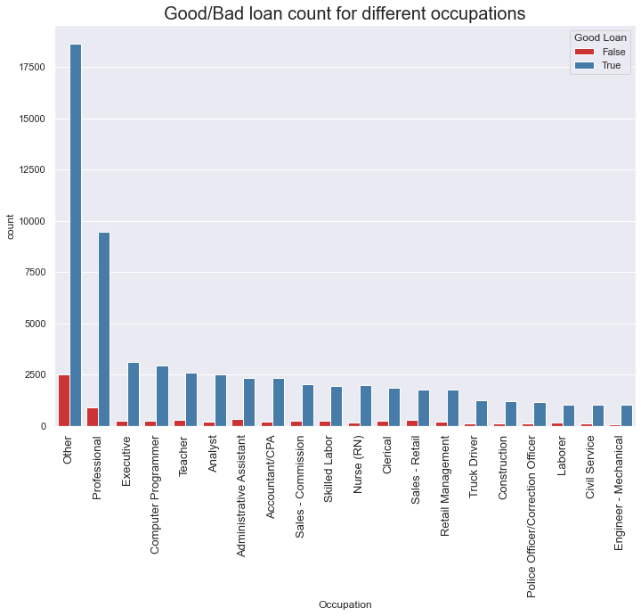

#### Current, Completed,Chargedoff and Defaulted are the majority data of the loan dataset (more than 90%) . Current loan has almost 69%

```
No handles with labels found to put in legend.
```

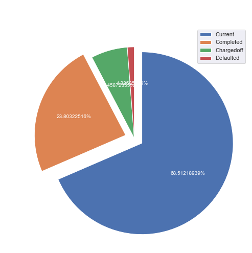

## Listing Loan Trend

### The listing loan amount was skyrocketing from 2013, current loan status cusotmer has more than 66% percentage of total loan, means bank business skyrocketing after 2013. Time impact LoanStatus obviously since 2011,most of the loan last to current was started from 2011,it going up tremendously after 2013. During the financial crisis in 2009, there is barely any loan record. there is a peak in 2011 suddenly lot of loan were completed.

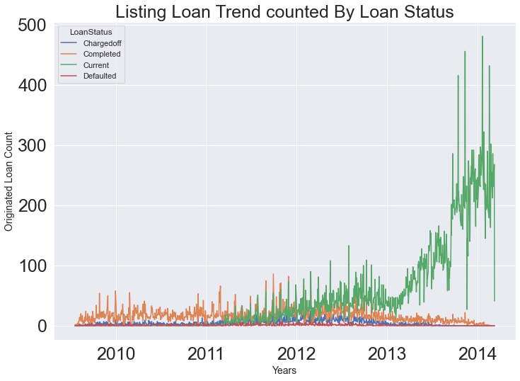

## Good Loan/Bad Loan historical trend

### it show there was a dip of good loan in 2013 but skyrocketing after then. bad loan not changing much for all time.

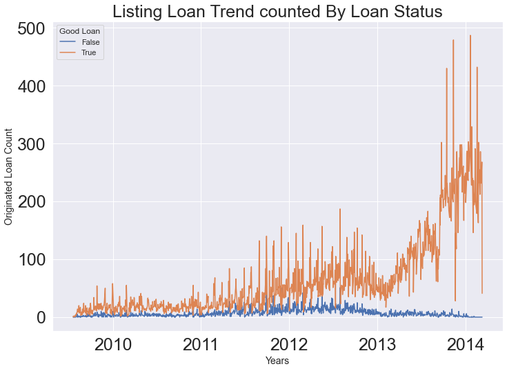

## Earning Historial Trend

### But on the contrary, Poor estimate return skyrocketiing after 2013, so looks like most current loan are estimated lower return than the bad loan.

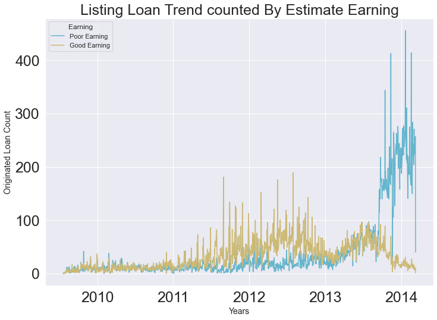

## Multivariate Exploration

### As i mentioned above, I hope this report can be used as a reference for periodic business summary, to review business situation from a macro or micro perspective, and find out the factors that affect the business (where, who, when, what), so the management can adjust the in time.

### so here i tried to find out 'when','where','what' affect the estimate return or loan status.

## Correlation of Different States ,Income and APR

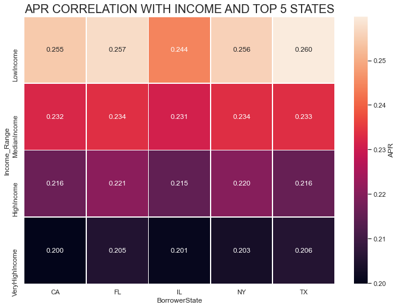

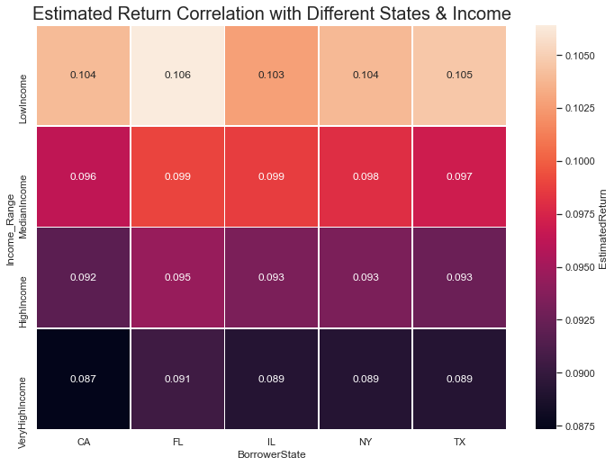

## Loan Status VS Estimate Return in top 5 states

### Apprently Good Loan status has lower estimate return than Not/good loan

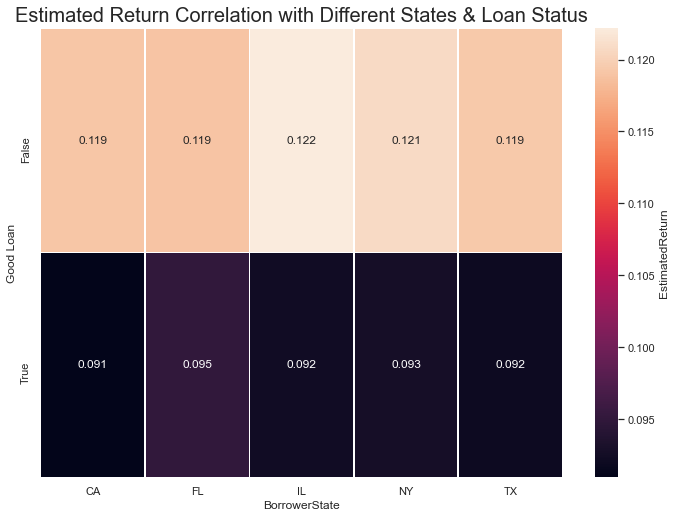

### Categorized the loans the bank try to avoid. and figure out what causing the those loan. They are:

## 'Charged Off' and 'Default'

#### A loan becomes “charged off” when there is no longer a reasonable expectation of further payments. Charge off typically occurs when a loan is 120 days or more past due. Learn more about the difference between “charge off” and “default”.

#### A Loans that are in "Default" are loans for which borrowers have failed to make payments for an extended period of time.A loan becomes “Charged Off” when there is no longer a reasonable expectation of further payments. Charge Off typically occurs when a loan is 120 days or more past due and there is no reasonable expectation of sufficient payment to prevent the charge off. In certain circumstances, loans may be charged off at an earlier or later date. Please note, loans for which borrowers have filed for bankruptcy may be charged off earlier based on the date of bankruptcy notification.

## Charge off/Defalut loan APR

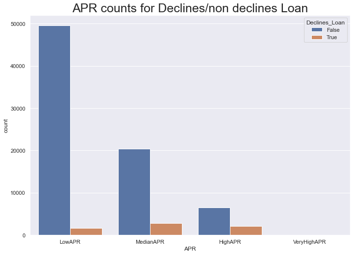

## Charge off/defalut loan vs Income Range

### 'Income' correlate with the 'precentage of become declines loan', the higher income, the lower chance become declins loan. if customer's income larger than100k, there is less than 5% chance become declines loan , but those not employed cusotmer, declins loan chance is 5 times than the 100k above customers.

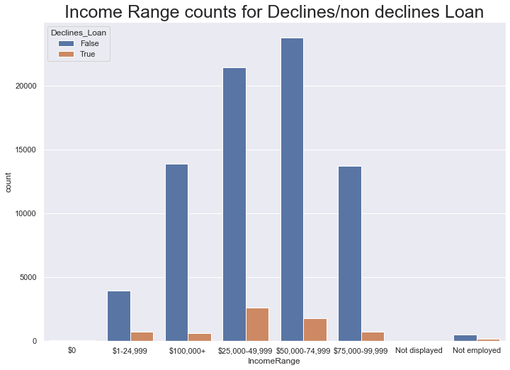

## Chargeoff/Defalut Loan VS Prosper Score

### 'income' and 'APR' are the factors that affect the loan status, most declines loan has lower monthly income and higher APR compare to undeclines loan, when Prosper Score is between range 2-6 and income are close or below 4k, there is high probability declines loan will happens

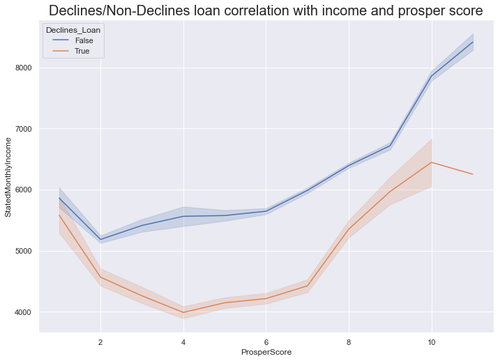

## Summary and Insights

#### As I mentioned before there are two major purpose I studying this dataset, find the correlation causing default and charge off loans, find out the features (who,where,when,what) affects the estimate return.

1. Here are the key words for most of the loans (CA, Current, Term 36, Income $50000-$74999, 2013, Q2,Q3. ProsperRating(C,D), Occupation: Other)
2. Answer(When)2013 is the turning point for loan business, the loan listing amount skyrocketing, the major listing Loan (current, complete) go up dramatically ; Q2 and Q3 are more busy quarter compare to q1 and q4 by average.
3. Answer(Who & Where)Customer’s Job title(who), Which state they living(where) does not affecting their loan status or estimate income.
4. Answering(What) By average speaking, Bad loan has higher average estimate income than Good Loan. (what).
5. Correlation: Income/APR(higher income, lower APR)； Apr/Estimate Return( High APR,Higher Return) ； Term/Return (Longer Term, Higher Return).
6. Estimate Income ( lower income, higher estimate return, who is your occupation or when you live doesn’t matter)‘income' and 'APR' are the factors that affect the loan status, most declines loan has lower monthly income and higher APR compare to not declines loan, when Prosper Score is between range 2-6 and income are close or below 4k, there is high probability declines loan will happen.
7. Higher Income and Lower APR, more chance not lead to charge off and default loan.

### Key Insights for Presentation:

There is contradiction between avoids bad loan and maximize estimate return. Because the bad loan has higher estimate average income 0.12 than good loan 0.09. and other plots are verify my finding. I guess the reason is bank charge more fee or interest for those high APR and low-income customer in order to cover the potential bad loan lost, that causing the bad loan average estimate return higher than good loan. But that doesn’t mean we don’t avoid bad loan, because if bank not handle charge/default loans properly, it will turn to lost, even though estimate return is higher but actually return are badly hurt because the bank spend more resource to handing the loan.